# Table of Contents

## Nicole Becker, "On my honor, as a student, I have neither given nor received unauthorized aid on this academic work."

# Data Analytics Lifecycle

```python
from IPython.display import Image
from IPython.core.display import HTML
Image(url= "https://upload.wikimedia.org/wikipedia/commons/b/b9/CRISP-DM_Process_Diagram.png")
```

[figure not shown]

```python
from IPython.display import Image
from IPython.core.display import HTML
Image(url= "http://www.dataprix.com/files/CRISPDM/Metodologia_CRISP_DM1_html_52cdbecf.png")
```

[figure not shown]

**Data understanding and data preparation** are two important phases in data analytics project.

These two stages are also called **"Extract Transform Loading" (ETL)**

# ETL (Extract Transform Loading): What? Why?

ETL represents a broad range of data transformation and processing techniques. ETL involves cleaning and transforming the data for data analysis.

## Garbage In, Garbage Out

Similar terms include **data munging**, **wrangling**, and **data transformation**

- Original data are not ready for analysis
- A typical data set or source contains many data quality issues
  - Missing values
  - Inconsistency
  - Inaccuracy
  - …
- Data preparation (or transformation) is a must

[figure not shown]

# How much time do data analysts spend cleaning and transforming data?

[figure not shown]

# This ETL module will cover:

- Basic techniques (data cleaning)
- Intermediate-level techniques (data transformation)
- Advanced techniques (data integration)

# Different data types

- **Numerical** refers to integer and real
  - Integer number (int): age
  - Real number (float): price
- **Object (or string)**
  - **Nominal** or polynominal means there are more than two different values in the attributes. For example, Maritial_Status (single, married, divorced), school year (freshman, sophomore, junior, senior)
  - **Binominal** means only two values. For example, Exam grade (Pass, Fail), Admission (Acceptance, Rejection), Purchase (Yes, Or), Cheating (True, False)

# Basic ETL techniques

This covers basic ETL techniques

Relevant online resources: 10 Minutes to pandas

- Numerical columns http://pandas.pydata.org/pandas-docs/stable/10min.html
- Categorical columns http://pandas-docs.github.io/pandas-docs-travis/categorical.html

```python
from IPython.display import YouTubeVideo
YouTubeVideo('DNyKDI9pn0Q')
```

[video not shown]

# Titanic Dataset

[figure not shown]

```python
# import python packages
import pandas as pd
import numpy as np
import matplotlib as plt
%matplotlib inline
```

```python
# import titanic_train.csv
ti=pd.read_csv("data/titanic_train.csv")
ti.head()
```

|  | PassengerId | Survived | Pclass | Name | Sex | Age | SibSp | Parch | Ticket | Fare | Cabin | Embarked |
| --- | --- | --- | --- | --- | --- | --- | --- | --- | --- | --- | --- | --- |
| 0 | 1 | 0 | 3 | Braund, Mr. Owen Harris | male | 22.00 | 1 | 0 | A/5 21171 | 7.2500 | NaN | S |
| 1 | 2 | 1 | 1 | Cumings, Mrs. John Bradley (Florence Briggs Th... | female | 350.00 | 1 | 0 | PC 17599 | 71.2833 | C85 | C |
| 2 | 3 | 1 | 3 | Heikkinen, Miss. Laina | hi | 26.00 | 0 | 0 | STON/O2. 3101282 | 7.9250 | NaN | S |
| 3 | 4 | 1 | 1 | Futrelle, Mrs. Jacques Heath (Lily May Peel) | hello | 35.00 | 1 | 0 | 113803 | 53.1000 | C123 | S |
| 4 | 5 | 0 | 3 | Allen, Mr. William Henry | male | 0.35 | 0 | 0 | 373450 | 8.0500 | NaN | S |

# Essential Data Transformation

### Finding out data type & missing values

```python
#data types & missing values
ti.info()
```

```
<class 'pandas.core.frame.DataFrame'>
RangeIndex: 891 entries, 0 to 890
Data columns (total 12 columns):
PassengerId    891 non-null int64
Survived       891 non-null int64
Pclass         891 non-null int64
Name           891 non-null object
Sex            891 non-null object
Age            714 non-null float64
SibSp          891 non-null int64
Parch          891 non-null int64
Ticket         891 non-null object
Fare           891 non-null float64
Cabin          204 non-null object
Embarked       889 non-null object
dtypes: float64(2), int64(5), object(5)
memory usage: 83.6+ KB
```

**Numerical columns**: PassengerId, Survived, Pclass, Age, SibSp, Parch, Fare

**Categorial columns**: Name, Sex, Ticket, Cabin, Embarked

There are some **missing values (Age, Cabin, Embarked)**

**This dataset needs data cleaning & transformation**

### Basic statistics

```python
#Describe shows a quick statistic summary of your data
#this is a good way to examine the numerical columns
ti.describe()
```

|  | PassengerId | Survived | Pclass | Age | SibSp | Parch | Fare |
| --- | --- | --- | --- | --- | --- | --- | --- |
| count | 891.000000 | 891.000000 | 891.000000 | 714.000000 | 891.000000 | 891.000000 | 891.000000 |
| mean | 446.000000 | 0.383838 | 2.308642 | 30.087563 | 0.523008 | 0.381594 | 32.204208 |
| std | 257.353842 | 0.486592 | 0.836071 | 18.863424 | 1.102743 | 0.806057 | 49.693429 |
| min | 1.000000 | 0.000000 | 1.000000 | 0.350000 | 0.000000 | 0.000000 | 0.000000 |
| 25% | 223.500000 | 0.000000 | 2.000000 | 20.000000 | 0.000000 | 0.000000 | 7.910400 |
| 50% | 446.000000 | 0.000000 | 3.000000 | 28.000000 | 0.000000 | 0.000000 | 14.454200 |
| 75% | 668.500000 | 1.000000 | 3.000000 | 38.000000 | 1.000000 | 0.000000 | 31.000000 |
| max | 891.000000 | 1.000000 | 3.000000 | 350.000000 | 8.000000 | 6.000000 | 512.329200 |

There are a number of **data quality issues**

- Someone or some people are 350 years old

```
array([[<matplotlib.axes._subplots.AxesSubplot object at 0x000001FE5E9F36D8>,
      dtype=object)
```

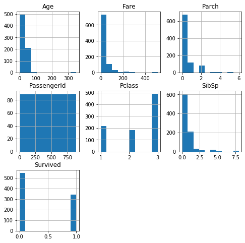

```python
ti.hist(figsize=(8,8))
```

```python
# describe for a single column
ti['Fare'].describe()
```

```
count    891.000000
mean      32.204208
std       49.693429
min        0.000000
25%        7.910400
50%       14.454200
75%       31.000000
max      512.329200
Name: Fare, dtype: float64
```

```python
# do this for categorical columns
ti['Embarked'].describe()
```

```
count     889
unique      3
top         S
freq      644
Name: Embarked, dtype: object
```

- Three different ports of departure (C = Cherbourg; Q = Queenstown; S = Southhampton)
- S is the most popular port. 644 boared on Titanic from S

```python
ti.groupby('Embarked').size()
```

```
Embarked
C    168
Q     77
S    644
dtype: int64
```

```python
# how many unique values in the Sex column
ti.groupby('Sex').size()
```

```
Sex
female    312
hello       1
hi          1
male      577
dtype: int64
```

**Is there any data quality issue here?**

**There's an issue with the results - "hi" and "hello" should not be a sex**

### Remove (unnessary) columns

```python
# remove an unnecessary column (PassengerId)

ti = ti.drop('PassengerId', axis=1)
ti.head()
```

|  | Survived | Pclass | Name | Sex | Age | SibSp | Parch | Ticket | Fare | Cabin | Embarked |
| --- | --- | --- | --- | --- | --- | --- | --- | --- | --- | --- | --- |
| 0 | 0 | 3 | Braund, Mr. Owen Harris | male | 22.00 | 1 | 0 | A/5 21171 | 7.2500 | NaN | S |
| 1 | 1 | 1 | Cumings, Mrs. John Bradley (Florence Briggs Th... | female | 350.00 | 1 | 0 | PC 17599 | 71.2833 | C85 | C |
| 2 | 1 | 3 | Heikkinen, Miss. Laina | hi | 26.00 | 0 | 0 | STON/O2. 3101282 | 7.9250 | NaN | S |
| 3 | 1 | 1 | Futrelle, Mrs. Jacques Heath (Lily May Peel) | hello | 35.00 | 1 | 0 | 113803 | 53.1000 | C123 | S |
| 4 | 0 | 3 | Allen, Mr. William Henry | male | 0.35 | 0 | 0 | 373450 | 8.0500 | NaN | S |

```python
# remove multiple columns (Name, Ticket, Cabin)

ti = ti.drop(['Name','Ticket'], axis=1)
ti.head()
```

|  | Survived | Pclass | Sex | Age | SibSp | Parch | Fare | Cabin | Embarked |
| --- | --- | --- | --- | --- | --- | --- | --- | --- | --- |
| 0 | 0 | 3 | male | 22.00 | 1 | 0 | 7.2500 | NaN | S |
| 1 | 1 | 1 | female | 350.00 | 1 | 0 | 71.2833 | C85 | C |
| 2 | 1 | 3 | hi | 26.00 | 0 | 0 | 7.9250 | NaN | S |
| 3 | 1 | 1 | hello | 35.00 | 1 | 0 | 53.1000 | C123 | S |
| 4 | 0 | 3 | male | 0.35 | 0 | 0 | 8.0500 | NaN | S |

```python
# can you remove Cabin column? (this column is not much useful for further analysis - predictive analytics)
ti = ti.drop(['Cabin'], axis=1)
ti.head()
```

|  | Survived | Pclass | Sex | Age | SibSp | Parch | Fare | Embarked |
| --- | --- | --- | --- | --- | --- | --- | --- | --- |
| 0 | 0 | 3 | male | 22.00 | 1 | 0 | 7.2500 | S |
| 1 | 1 | 1 | female | 350.00 | 1 | 0 | 71.2833 | C |
| 2 | 1 | 3 | hi | 26.00 | 0 | 0 | 7.9250 | S |
| 3 | 1 | 1 | hello | 35.00 | 1 | 0 | 53.1000 | S |
| 4 | 0 | 3 | male | 0.35 | 0 | 0 | 8.0500 | S |

```python
# how many missing values in each column or variable
ti.isnull().sum()
```

```
Survived      0
Pclass        0
Sex           0
Age         177
SibSp         0
Parch         0
Fare          0
Embarked      2
dtype: int64
```

### Handling missing value

There are different ways to handle missing values

- drop them all
- replace with certain values (e.g., mean, mode, median, specific value)

Recommended heuristics for handling missing values in real-world datasets

1. Remove unnecessary (or unmeaningful) columns (e.g., Ticket number): "unnecessary" means those columns you don't consider for the analysis. For example, it is obvious that there is no need to analyze "ticker numbers".
2. Some columns' missing values could be replaced with a specific value (e.g., mean, median), while replacement is not possible for other columns. For the latter case, drop the rows with missing values "mindfully".

```python
#handling missing value: remove the rows with any missing value
ti_rev = ti.dropna()
ti_rev.info()
```

```
<class 'pandas.core.frame.DataFrame'>
Int64Index: 712 entries, 0 to 890
Data columns (total 8 columns):
Survived    712 non-null int64
Pclass      712 non-null int64
Sex         712 non-null object
Age         712 non-null float64
SibSp       712 non-null int64
Parch       712 non-null int64
Fare        712 non-null float64
Embarked    712 non-null object
dtypes: float64(2), int64(4), object(2)
memory usage: 50.1+ KB
```

Now, the dataset has 712 rows. No rows with missing values. This is an aggressive approach.

```python
# replace null value with the most popular value in a categorial columns
ti = ti.fillna({'Embarked': 'S'})
ti.isnull().sum()
```

```
Survived      0
Pclass        0
Sex           0
Age         177
SibSp         0
Parch         0
Fare          0
Embarked      0
dtype: int64
```

```python
ti['Age'].median()
```

```
28.0
```

```python
# replace null value with the median value
ti = ti.fillna({'Age': 28})
ti.isnull().sum()
```

```
Survived    0
Pclass      0
Sex         0
Age         0
SibSp       0
Parch       0
Fare        0
Embarked    0
dtype: int64
```

```python
# what would you do to replace null values with the mean value
#find mean value
ti['Age'].mean()
```

```
29.67286195286195
```

```python
#replace null with mean value
ti = ti.fillna({'Age': 3})
ti.isnull().sum()
```

```
Survived    0
Pclass      0
Sex         0
Age         0
SibSp       0
Parch       0
Fare        0
Embarked    0
dtype: int64
```

### Handling Inaccurate/Inconsistent Data

- replace inaccurate values with null values and remove the row(s) with missing values
- replace inaccurate values with different values

```python
# hello in Sex is inaccurate ...replacing inaccurate value with null value
ti = ti.replace('hello', np.nan)
ti.head()
```

|  | Survived | Pclass | Sex | Age | SibSp | Parch | Fare | Embarked |
| --- | --- | --- | --- | --- | --- | --- | --- | --- |
| 0 | 0 | 3 | male | 22.00 | 1 | 0 | 7.2500 | S |
| 1 | 1 | 1 | female | 350.00 | 1 | 0 | 71.2833 | C |
| 2 | 1 | 3 | hi | 26.00 | 0 | 0 | 7.9250 | S |
| 3 | 1 | 1 | NaN | 35.00 | 1 | 0 | 53.1000 | S |
| 4 | 0 | 3 | male | 0.35 | 0 | 0 | 8.0500 | S |

```python
ti = ti.dropna()
ti.head()
```

|  | Survived | Pclass | Sex | Age | SibSp | Parch | Fare | Embarked |
| --- | --- | --- | --- | --- | --- | --- | --- | --- |
| 0 | 0 | 3 | male | 22.00 | 1 | 0 | 7.2500 | S |
| 1 | 1 | 1 | female | 350.00 | 1 | 0 | 71.2833 | C |
| 2 | 1 | 3 | hi | 26.00 | 0 | 0 | 7.9250 | S |
| 4 | 0 | 3 | male | 0.35 | 0 | 0 | 8.0500 | S |
| 5 | 0 | 3 | male | 28.00 | 0 | 0 | 8.4583 | Q |

```python
# 350 is an inaccurate value for age and should be replaced by 35
# changinge single value with replace
ti = ti.replace({'Age': 350}, {'Age': 35})
ti.head()
```

|  | Survived | Pclass | Sex | Age | SibSp | Parch | Fare | Embarked |
| --- | --- | --- | --- | --- | --- | --- | --- | --- |
| 0 | 0 | 3 | male | 22.00 | 1 | 0 | 7.2500 | S |
| 1 | 1 | 1 | female | 35.00 | 1 | 0 | 71.2833 | C |
| 2 | 1 | 3 | hi | 26.00 | 0 | 0 | 7.9250 | S |
| 4 | 0 | 3 | male | 0.35 | 0 | 0 | 8.0500 | S |
| 5 | 0 | 3 | male | 28.00 | 0 | 0 | 8.4583 | Q |

```python
# instead of replacing hello with null value and removing the row,
# can you replace hi with the most popular value (male) in the categorical column?
```

```python
#find most popular value
ti.groupby('Sex').size()
```

```
Sex
female    312
hi          1
male      577
dtype: int64
```

```python
#replace null with male
```

```python
ti = ti.replace('hi', 'male')
ti.head()
```

|  | Survived | Pclass | Sex | Age | SibSp | Parch | Fare | Embarked |
| --- | --- | --- | --- | --- | --- | --- | --- | --- |
| 0 | 0 | 3 | male | 22.00 | 1 | 0 | 7.2500 | S |
| 1 | 1 | 1 | female | 35.00 | 1 | 0 | 71.2833 | C |
| 2 | 1 | 3 | male | 26.00 | 0 | 0 | 7.9250 | S |
| 4 | 0 | 3 | male | 0.35 | 0 | 0 | 8.0500 | S |
| 5 | 0 | 3 | male | 28.00 | 0 | 0 | 8.4583 | Q |

```python
# Now, there should be male and female in the Sex column

# chaing categorical values with map
ti['Sex'] = ti['Sex'].map({'female': 0, 'male': 1})
ti.head()
```

|  | Survived | Pclass | Sex | Age | SibSp | Parch | Fare | Embarked |
| --- | --- | --- | --- | --- | --- | --- | --- | --- |
| 0 | 0 | 3 | 1 | 22.00 | 1 | 0 | 7.2500 | S |
| 1 | 1 | 1 | 0 | 35.00 | 1 | 0 | 71.2833 | C |
| 2 | 1 | 3 | 1 | 26.00 | 0 | 0 | 7.9250 | S |
| 4 | 0 | 3 | 1 | 0.35 | 0 | 0 | 8.0500 | S |
| 5 | 0 | 3 | 1 | 28.00 | 0 | 0 | 8.4583 | Q |

```python
# when you analyze data, it is better to transform categorical values to numerical values
# can you convert S, C, Q (Embarked) to 1, 2, 3
ti['Emarked'] = ti['Embarked'].map({'S': 1, 'C': 2, 'Q' : 3})
ti.head()
```

|  | Survived | Pclass | Sex | Age | SibSp | Parch | Fare | Embarked | Emarked |
| --- | --- | --- | --- | --- | --- | --- | --- | --- | --- |
| 0 | 0 | 3 | 1 | 22.00 | 1 | 0 | 7.2500 | S | 1 |
| 1 | 1 | 1 | 0 | 35.00 | 1 | 0 | 71.2833 | C | 2 |
| 2 | 1 | 3 | 1 | 26.00 | 0 | 0 | 7.9250 | S | 1 |
| 4 | 0 | 3 | 1 | 0.35 | 0 | 0 | 8.0500 | S | 1 |
| 5 | 0 | 3 | 1 | 28.00 | 0 | 0 | 8.4583 | Q | 3 |

After applying multiple techniques of data cleaning, the data looks good now. Perhaps, this cleaned data can be used for analysis & builing predictive model. The predictive model would predict who is likely to survive, while using Survived as y value

```python
# if the data cleaning is done, you may want to export it as csv or excel

ti.to_csv("data/ti_cleaned.csv")
```

# Intermediate-level Data Transformation

```python
# create new columns
ti['CurrentAge'] = ti['Age'] + 90
ti.head()
```

|  | Survived | Pclass | Sex | Age | SibSp | Parch | Fare | Embarked | Emarked | CurrentAge |
| --- | --- | --- | --- | --- | --- | --- | --- | --- | --- | --- |
| 0 | 0 | 3 | 1 | 22.00 | 1 | 0 | 7.2500 | S | 1 | 112.00 |
| 1 | 1 | 1 | 0 | 35.00 | 1 | 0 | 71.2833 | C | 2 | 125.00 |
| 2 | 1 | 3 | 1 | 26.00 | 0 | 0 | 7.9250 | S | 1 | 116.00 |
| 4 | 0 | 3 | 1 | 0.35 | 0 | 0 | 8.0500 | S | 1 | 90.35 |
| 5 | 0 | 3 | 1 | 28.00 | 0 | 0 | 8.4583 | Q | 3 | 118.00 |

```python
# can you create a new column ("discount") based on Fare?
ti['Discount'] = ti['Fare'] * 0.25
ti.head()
```

|  | Survived | Pclass | Sex | Age | SibSp | Parch | Fare | Embarked | Emarked | CurrentAge | Discount |
| --- | --- | --- | --- | --- | --- | --- | --- | --- | --- | --- | --- |
| 0 | 0 | 3 | 1 | 22.00 | 1 | 0 | 7.2500 | S | 1 | 112.00 | 1.812500 |
| 1 | 1 | 1 | 0 | 35.00 | 1 | 0 | 71.2833 | C | 2 | 125.00 | 17.820825 |
| 2 | 1 | 3 | 1 | 26.00 | 0 | 0 | 7.9250 | S | 1 | 116.00 | 1.981250 |
| 4 | 0 | 3 | 1 | 0.35 | 0 | 0 | 8.0500 | S | 1 | 90.35 | 2.012500 |
| 5 | 0 | 3 | 1 | 28.00 | 0 | 0 | 8.4583 | Q | 3 | 118.00 | 2.114575 |

```python
# create a copy of existing column
ti['DeparturePort'] = ti['Embarked']
ti.head()
```

|  | Survived | Pclass | Sex | Age | SibSp | Parch | Fare | Embarked | Emarked | CurrentAge | Discount | DeparturePort |
| --- | --- | --- | --- | --- | --- | --- | --- | --- | --- | --- | --- | --- |
| 0 | 0 | 3 | 1 | 22.00 | 1 | 0 | 7.2500 | S | 1 | 112.00 | 1.812500 | S |
| 1 | 1 | 1 | 0 | 35.00 | 1 | 0 | 71.2833 | C | 2 | 125.00 | 17.820825 | C |
| 2 | 1 | 3 | 1 | 26.00 | 0 | 0 | 7.9250 | S | 1 | 116.00 | 1.981250 | S |
| 4 | 0 | 3 | 1 | 0.35 | 0 | 0 | 8.0500 | S | 1 | 90.35 | 2.012500 | S |
| 5 | 0 | 3 | 1 | 28.00 | 0 | 0 | 8.4583 | Q | 3 | 118.00 | 2.114575 | Q |

```python
# rename columns
ti = ti.rename(columns={'Pclass': 'PassengerClass'})
ti.head()
```

|  | Survived | PassengerClass | Sex | Age | SibSp | Parch | Fare | Embarked | Emarked | CurrentAge | Discount | DeparturePort |
| --- | --- | --- | --- | --- | --- | --- | --- | --- | --- | --- | --- | --- |
| 0 | 0 | 3 | 1 | 22.00 | 1 | 0 | 7.2500 | S | 1 | 112.00 | 1.812500 | S |
| 1 | 1 | 1 | 0 | 35.00 | 1 | 0 | 71.2833 | C | 2 | 125.00 | 17.820825 | C |
| 2 | 1 | 3 | 1 | 26.00 | 0 | 0 | 7.9250 | S | 1 | 116.00 | 1.981250 | S |
| 4 | 0 | 3 | 1 | 0.35 | 0 | 0 | 8.0500 | S | 1 | 90.35 | 2.012500 | S |
| 5 | 0 | 3 | 1 | 28.00 | 0 | 0 | 8.4583 | Q | 3 | 118.00 | 2.114575 | Q |

```python
# Can you rename discount as Disc
ti = ti.rename(columns={'Discount': 'Disc'})
ti.head()
```

|  | Survived | PassengerClass | Sex | Age | SibSp | Parch | Fare | Embarked | Emarked | CurrentAge | Disc | DeparturePort |
| --- | --- | --- | --- | --- | --- | --- | --- | --- | --- | --- | --- | --- |
| 0 | 0 | 3 | 1 | 22.00 | 1 | 0 | 7.2500 | S | 1 | 112.00 | 1.812500 | S |
| 1 | 1 | 1 | 0 | 35.00 | 1 | 0 | 71.2833 | C | 2 | 125.00 | 17.820825 | C |
| 2 | 1 | 3 | 1 | 26.00 | 0 | 0 | 7.9250 | S | 1 | 116.00 | 1.981250 | S |
| 4 | 0 | 3 | 1 | 0.35 | 0 | 0 | 8.0500 | S | 1 | 90.35 | 2.012500 | S |
| 5 | 0 | 3 | 1 | 28.00 | 0 | 0 | 8.4583 | Q | 3 | 118.00 | 2.114575 | Q |

```python
# create bins (discretize)

ti['Fare_Category'] = pd.qcut(ti['Fare'], 5)
ti.head()
```

|  | Survived | PassengerClass | Sex | Age | SibSp | Parch | Fare | Embarked | Emarked | CurrentAge | Disc | DeparturePort | Fare_Category |
| --- | --- | --- | --- | --- | --- | --- | --- | --- | --- | --- | --- | --- | --- |
| 0 | 0 | 3 | 1 | 22.00 | 1 | 0 | 7.2500 | S | 1 | 112.00 | 1.812500 | S | (-0.001, 7.854] |
| 1 | 1 | 1 | 0 | 35.00 | 1 | 0 | 71.2833 | C | 2 | 125.00 | 17.820825 | C | (39.688, 512.329] |
| 2 | 1 | 3 | 1 | 26.00 | 0 | 0 | 7.9250 | S | 1 | 116.00 | 1.981250 | S | (7.854, 10.5] |
| 4 | 0 | 3 | 1 | 0.35 | 0 | 0 | 8.0500 | S | 1 | 90.35 | 2.012500 | S | (7.854, 10.5] |
| 5 | 0 | 3 | 1 | 28.00 | 0 | 0 | 8.4583 | Q | 3 | 118.00 | 2.114575 | Q | (7.854, 10.5] |

```python
ti.groupby('Fare_Category').count()
```

| Fare_Category | Survived | PassengerClass | Sex | Age | SibSp | Parch | Fare | Embarked | Emarked | CurrentAge | Disc | DeparturePort |
| --- | --- | --- | --- | --- | --- | --- | --- | --- | --- | --- | --- | --- |
| (-0.001, 7.854] | 179 | 179 | 179 | 179 | 179 | 179 | 179 | 179 | 179 | 179 | 179 | 179 |
| (7.854, 10.5] | 184 | 184 | 184 | 184 | 184 | 184 | 184 | 184 | 184 | 184 | 184 | 184 |
| (10.5, 21.317] | 171 | 171 | 171 | 171 | 171 | 171 | 171 | 171 | 171 | 171 | 171 | 171 |
| (21.317, 39.688] | 181 | 181 | 181 | 181 | 181 | 181 | 181 | 181 | 181 | 181 | 181 | 181 |
| (39.688, 512.329] | 175 | 175 | 175 | 175 | 175 | 175 | 175 | 175 | 175 | 175 | 175 | 175 |

```python
#rename the name of those bins to 1, 2, 3, 4, 5
ti['Fare_Category_Labels'] = pd.qcut(ti['Fare'], 5, labels=['1', '2', '3', '4', '5'])
ti.head()
```

|  | Survived | PassengerClass | Sex | Age | SibSp | Parch | Fare | Embarked | Emarked | CurrentAge | Disc | DeparturePort | Fare_Category | Fare_Category_Labels |
| --- | --- | --- | --- | --- | --- | --- | --- | --- | --- | --- | --- | --- | --- | --- |
| 0 | 0 | 3 | 1 | 22.00 | 1 | 0 | 7.2500 | S | 1 | 112.00 | 1.812500 | S | (-0.001, 7.854] | 1 |
| 1 | 1 | 1 | 0 | 35.00 | 1 | 0 | 71.2833 | C | 2 | 125.00 | 17.820825 | C | (39.688, 512.329] | 5 |
| 2 | 1 | 3 | 1 | 26.00 | 0 | 0 | 7.9250 | S | 1 | 116.00 | 1.981250 | S | (7.854, 10.5] | 2 |
| 4 | 0 | 3 | 1 | 0.35 | 0 | 0 | 8.0500 | S | 1 | 90.35 | 2.012500 | S | (7.854, 10.5] | 2 |
| 5 | 0 | 3 | 1 | 28.00 | 0 | 0 | 8.4583 | Q | 3 | 118.00 | 2.114575 | Q | (7.854, 10.5] | 2 |

```python
#Survived is categorical data type. What if I want to change it to integer
ti['Survived'] = ti['Survived'].astype(int)
ti.info()
```

```
<class 'pandas.core.frame.DataFrame'>
Int64Index: 890 entries, 0 to 890
Data columns (total 14 columns):
Survived                890 non-null int32
PassengerClass          890 non-null int64
Sex                     890 non-null int64
Age                     890 non-null float64
SibSp                   890 non-null int64
Parch                   890 non-null int64
Fare                    890 non-null float64
Embarked                890 non-null object
Emarked                 890 non-null int64
CurrentAge              890 non-null float64
Disc                    890 non-null float64
DeparturePort           890 non-null object
Fare_Category           890 non-null category
Fare_Category_Labels    890 non-null category
dtypes: category(2), float64(4), int32(1), int64(5), object(2)
memory usage: 88.9+ KB
```

```python
# filtering or selecting columns

#selecting two columns and assigning to a new variable or dataset called "ti_2"
ti_2 = ti[['Survived','Age']]
ti_2.head()
```

|  | Survived | Age |
| --- | --- | --- |
| 0 | 0 | 22.00 |
| 1 | 1 | 35.00 |
| 2 | 1 | 26.00 |
| 4 | 0 | 0.35 |
| 5 | 0 | 28.00 |

```python
# can you select two other columns. use a different variable name (ti_3)
ti_3 = ti[['Sex','DeparturePort']]
ti_3.head()
```

|  | Sex | DeparturePort |
| --- | --- | --- |
| 0 | 1 | S |
| 1 | 0 | C |
| 2 | 1 | S |
| 4 | 1 | S |
| 5 | 1 | Q |

```python
# Filtering or Selecting rows

#single criterion
ti[(ti['Fare'] > 200)]
```

|  | Survived | PassengerClass | Sex | Age | SibSp | Parch | Fare | Embarked | Emarked | CurrentAge | Disc | DeparturePort | Fare_Category | Fare_Category_Labels |
| --- | --- | --- | --- | --- | --- | --- | --- | --- | --- | --- | --- | --- | --- | --- |
| 27 | 0 | 1 | 1 | 19.0 | 3 | 2 | 263.0000 | S | 1 | 109.0 | 65.750000 | S | (39.688, 512.329] | 5 |
| 88 | 1 | 1 | 0 | 23.0 | 3 | 2 | 263.0000 | S | 1 | 113.0 | 65.750000 | S | (39.688, 512.329] | 5 |
| 118 | 0 | 1 | 1 | 24.0 | 0 | 1 | 247.5208 | C | 2 | 114.0 | 61.880200 | C | (39.688, 512.329] | 5 |
| 258 | 1 | 1 | 0 | 35.0 | 0 | 0 | 512.3292 | C | 2 | 125.0 | 128.082300 | C | (39.688, 512.329] | 5 |
| 299 | 1 | 1 | 0 | 50.0 | 0 | 1 | 247.5208 | C | 2 | 140.0 | 61.880200 | C | (39.688, 512.329] | 5 |
| 311 | 1 | 1 | 0 | 18.0 | 2 | 2 | 262.3750 | C | 2 | 108.0 | 65.593750 | C | (39.688, 512.329] | 5 |
| 341 | 1 | 1 | 0 | 24.0 | 3 | 2 | 263.0000 | S | 1 | 114.0 | 65.750000 | S | (39.688, 512.329] | 5 |
| 377 | 0 | 1 | 1 | 27.0 | 0 | 2 | 211.5000 | C | 2 | 117.0 | 52.875000 | C | (39.688, 512.329] | 5 |
| 380 | 1 | 1 | 0 | 42.0 | 0 | 0 | 227.5250 | C | 2 | 132.0 | 56.881250 | C | (39.688, 512.329] | 5 |
| 438 | 0 | 1 | 1 | 64.0 | 1 | 4 | 263.0000 | S | 1 | 154.0 | 65.750000 | S | (39.688, 512.329] | 5 |
| 527 | 0 | 1 | 1 | 28.0 | 0 | 0 | 221.7792 | S | 1 | 118.0 | 55.444800 | S | (39.688, 512.329] | 5 |
| 557 | 0 | 1 | 1 | 28.0 | 0 | 0 | 227.5250 | C | 2 | 118.0 | 56.881250 | C | (39.688, 512.329] | 5 |
| 679 | 1 | 1 | 1 | 36.0 | 0 | 1 | 512.3292 | C | 2 | 126.0 | 128.082300 | C | (39.688, 512.329] | 5 |
| 689 | 1 | 1 | 0 | 15.0 | 0 | 1 | 211.3375 | S | 1 | 105.0 | 52.834375 | S | (39.688, 512.329] | 5 |
| 700 | 1 | 1 | 0 | 18.0 | 1 | 0 | 227.5250 | C | 2 | 108.0 | 56.881250 | C | (39.688, 512.329] | 5 |
| 716 | 1 | 1 | 0 | 38.0 | 0 | 0 | 227.5250 | C | 2 | 128.0 | 56.881250 | C | (39.688, 512.329] | 5 |
| 730 | 1 | 1 | 0 | 29.0 | 0 | 0 | 211.3375 | S | 1 | 119.0 | 52.834375 | S | (39.688, 512.329] | 5 |
| 737 | 1 | 1 | 1 | 35.0 | 0 | 0 | 512.3292 | C | 2 | 125.0 | 128.082300 | C | (39.688, 512.329] | 5 |
| 742 | 1 | 1 | 0 | 21.0 | 2 | 2 | 262.3750 | C | 2 | 111.0 | 65.593750 | C | (39.688, 512.329] | 5 |
| 779 | 1 | 1 | 0 | 43.0 | 0 | 1 | 211.3375 | S | 1 | 133.0 | 52.834375 | S | (39.688, 512.329] | 5 |

```python
#Multiple conditions have to be combined using &
ti[(ti['Fare'] > 200) & (ti['Survived'] == 1)]
```

|  | Survived | PassengerClass | Sex | Age | SibSp | Parch | Fare | Embarked | Emarked | CurrentAge | Disc | DeparturePort | Fare_Category | Fare_Category_Labels |
| --- | --- | --- | --- | --- | --- | --- | --- | --- | --- | --- | --- | --- | --- | --- |
| 88 | 1 | 1 | 0 | 23.0 | 3 | 2 | 263.0000 | S | 1 | 113.0 | 65.750000 | S | (39.688, 512.329] | 5 |
| 258 | 1 | 1 | 0 | 35.0 | 0 | 0 | 512.3292 | C | 2 | 125.0 | 128.082300 | C | (39.688, 512.329] | 5 |
| 299 | 1 | 1 | 0 | 50.0 | 0 | 1 | 247.5208 | C | 2 | 140.0 | 61.880200 | C | (39.688, 512.329] | 5 |
| 311 | 1 | 1 | 0 | 18.0 | 2 | 2 | 262.3750 | C | 2 | 108.0 | 65.593750 | C | (39.688, 512.329] | 5 |
| 341 | 1 | 1 | 0 | 24.0 | 3 | 2 | 263.0000 | S | 1 | 114.0 | 65.750000 | S | (39.688, 512.329] | 5 |
| 380 | 1 | 1 | 0 | 42.0 | 0 | 0 | 227.5250 | C | 2 | 132.0 | 56.881250 | C | (39.688, 512.329] | 5 |
| 679 | 1 | 1 | 1 | 36.0 | 0 | 1 | 512.3292 | C | 2 | 126.0 | 128.082300 | C | (39.688, 512.329] | 5 |
| 689 | 1 | 1 | 0 | 15.0 | 0 | 1 | 211.3375 | S | 1 | 105.0 | 52.834375 | S | (39.688, 512.329] | 5 |
| 700 | 1 | 1 | 0 | 18.0 | 1 | 0 | 227.5250 | C | 2 | 108.0 | 56.881250 | C | (39.688, 512.329] | 5 |
| 716 | 1 | 1 | 0 | 38.0 | 0 | 0 | 227.5250 | C | 2 | 128.0 | 56.881250 | C | (39.688, 512.329] | 5 |
| 730 | 1 | 1 | 0 | 29.0 | 0 | 0 | 211.3375 | S | 1 | 119.0 | 52.834375 | S | (39.688, 512.329] | 5 |
| 737 | 1 | 1 | 1 | 35.0 | 0 | 0 | 512.3292 | C | 2 | 125.0 | 128.082300 | C | (39.688, 512.329] | 5 |
| 742 | 1 | 1 | 0 | 21.0 | 2 | 2 | 262.3750 | C | 2 | 111.0 | 65.593750 | C | (39.688, 512.329] | 5 |
| 779 | 1 | 1 | 0 | 43.0 | 0 | 1 | 211.3375 | S | 1 | 133.0 | 52.834375 | S | (39.688, 512.329] | 5 |

Some passengers in upper class did not survived.

```python
# can you create a filter using a criterion?
ti[(ti['Sex'] == 1)]
```

|  | Survived | PassengerClass | Sex | Age | SibSp | Parch | Fare | Embarked | Emarked | CurrentAge | Disc | DeparturePort | Fare_Category | Fare_Category_Labels |
| --- | --- | --- | --- | --- | --- | --- | --- | --- | --- | --- | --- | --- | --- | --- |
| 0 | 0 | 3 | 1 | 22.00 | 1 | 0 | 7.2500 | S | 1 | 112.00 | 1.812500 | S | (-0.001, 7.854] | 1 |
| 2 | 1 | 3 | 1 | 26.00 | 0 | 0 | 7.9250 | S | 1 | 116.00 | 1.981250 | S | (7.854, 10.5] | 2 |
| 4 | 0 | 3 | 1 | 0.35 | 0 | 0 | 8.0500 | S | 1 | 90.35 | 2.012500 | S | (7.854, 10.5] | 2 |
| 5 | 0 | 3 | 1 | 28.00 | 0 | 0 | 8.4583 | Q | 3 | 118.00 | 2.114575 | Q | (7.854, 10.5] | 2 |
| 6 | 0 | 1 | 1 | 54.00 | 0 | 0 | 51.8625 | S | 1 | 144.00 | 12.965625 | S | (39.688, 512.329] | 5 |
| 7 | 0 | 3 | 1 | 2.00 | 3 | 1 | 21.0750 | S | 1 | 92.00 | 5.268750 | S | (10.5, 21.317] | 3 |
| 12 | 0 | 3 | 1 | 20.00 | 0 | 0 | 8.0500 | S | 1 | 110.00 | 2.012500 | S | (7.854, 10.5] | 2 |
| 13 | 0 | 3 | 1 | 39.00 | 1 | 5 | 31.2750 | S | 1 | 129.00 | 7.818750 | S | (21.317, 39.688] | 4 |
| 16 | 0 | 3 | 1 | 2.00 | 4 | 1 | 29.1250 | Q | 3 | 92.00 | 7.281250 | Q | (21.317, 39.688] | 4 |
| 17 | 1 | 2 | 1 | 28.00 | 0 | 0 | 13.0000 | S | 1 | 118.00 | 3.250000 | S | (10.5, 21.317] | 3 |
| 20 | 0 | 2 | 1 | 35.00 | 0 | 0 | 26.0000 | S | 1 | 125.00 | 6.500000 | S | (21.317, 39.688] | 4 |
| 21 | 1 | 2 | 1 | 34.00 | 0 | 0 | 13.0000 | S | 1 | 124.00 | 3.250000 | S | (10.5, 21.317] | 3 |
| 23 | 1 | 1 | 1 | 28.00 | 0 | 0 | 35.5000 | S | 1 | 118.00 | 8.875000 | S | (21.317, 39.688] | 4 |
| 26 | 0 | 3 | 1 | 28.00 | 0 | 0 | 7.2250 | C | 2 | 118.00 | 1.806250 | C | (-0.001, 7.854] | 1 |
| 27 | 0 | 1 | 1 | 19.00 | 3 | 2 | 263.0000 | S | 1 | 109.00 | 65.750000 | S | (39.688, 512.329] | 5 |
| 29 | 0 | 3 | 1 | 28.00 | 0 | 0 | 7.8958 | S | 1 | 118.00 | 1.973950 | S | (7.854, 10.5] | 2 |
| 30 | 0 | 1 | 1 | 40.00 | 0 | 0 | 27.7208 | C | 2 | 130.00 | 6.930200 | C | (21.317, 39.688] | 4 |
| 33 | 0 | 2 | 1 | 66.00 | 0 | 0 | 10.5000 | S | 1 | 156.00 | 2.625000 | S | (7.854, 10.5] | 2 |
| 34 | 0 | 1 | 1 | 28.00 | 1 | 0 | 82.1708 | C | 2 | 118.00 | 20.542700 | C | (39.688, 512.329] | 5 |
| 35 | 0 | 1 | 1 | 42.00 | 1 | 0 | 52.0000 | S | 1 | 132.00 | 13.000000 | S | (39.688, 512.329] | 5 |
| 36 | 1 | 3 | 1 | 28.00 | 0 | 0 | 7.2292 | C | 2 | 118.00 | 1.807300 | C | (-0.001, 7.854] | 1 |
| 37 | 0 | 3 | 1 | 21.00 | 0 | 0 | 8.0500 | S | 1 | 111.00 | 2.012500 | S | (7.854, 10.5] | 2 |
| 42 | 0 | 3 | 1 | 28.00 | 0 | 0 | 7.8958 | C | 2 | 118.00 | 1.973950 | C | (7.854, 10.5] | 2 |
| 45 | 0 | 3 | 1 | 28.00 | 0 | 0 | 8.0500 | S | 1 | 118.00 | 2.012500 | S | (7.854, 10.5] | 2 |
| 46 | 0 | 3 | 1 | 28.00 | 1 | 0 | 15.5000 | Q | 3 | 118.00 | 3.875000 | Q | (10.5, 21.317] | 3 |
| 48 | 0 | 3 | 1 | 28.00 | 2 | 0 | 21.6792 | C | 2 | 118.00 | 5.419800 | C | (21.317, 39.688] | 4 |
| 50 | 0 | 3 | 1 | 7.00 | 4 | 1 | 39.6875 | S | 1 | 97.00 | 9.921875 | S | (21.317, 39.688] | 4 |
| 51 | 0 | 3 | 1 | 21.00 | 0 | 0 | 7.8000 | S | 1 | 111.00 | 1.950000 | S | (-0.001, 7.854] | 1 |
| 54 | 0 | 1 | 1 | 65.00 | 0 | 1 | 61.9792 | C | 2 | 155.00 | 15.494800 | C | (39.688, 512.329] | 5 |
| 55 | 1 | 1 | 1 | 28.00 | 0 | 0 | 35.5000 | S | 1 | 118.00 | 8.875000 | S | (21.317, 39.688] | 4 |
| ... | ... | ... | ... | ... | ... | ... | ... | ... | ... | ... | ... | ... | ... | ... |
| 840 | 0 | 3 | 1 | 20.00 | 0 | 0 | 7.9250 | S | 1 | 110.00 | 1.981250 | S | (7.854, 10.5] | 2 |
| 841 | 0 | 2 | 1 | 16.00 | 0 | 0 | 10.5000 | S | 1 | 106.00 | 2.625000 | S | (7.854, 10.5] | 2 |
| 843 | 0 | 3 | 1 | 34.50 | 0 | 0 | 6.4375 | C | 2 | 124.50 | 1.609375 | C | (-0.001, 7.854] | 1 |
| 844 | 0 | 3 | 1 | 17.00 | 0 | 0 | 8.6625 | S | 1 | 107.00 | 2.165625 | S | (7.854, 10.5] | 2 |
| 845 | 0 | 3 | 1 | 42.00 | 0 | 0 | 7.5500 | S | 1 | 132.00 | 1.887500 | S | (-0.001, 7.854] | 1 |
| 846 | 0 | 3 | 1 | 28.00 | 8 | 2 | 69.5500 | S | 1 | 118.00 | 17.387500 | S | (39.688, 512.329] | 5 |
| 847 | 0 | 3 | 1 | 35.00 | 0 | 0 | 7.8958 | C | 2 | 125.00 | 1.973950 | C | (7.854, 10.5] | 2 |
| 848 | 0 | 2 | 1 | 28.00 | 0 | 1 | 33.0000 | S | 1 | 118.00 | 8.250000 | S | (21.317, 39.688] | 4 |
| 850 | 0 | 3 | 1 | 4.00 | 4 | 2 | 31.2750 | S | 1 | 94.00 | 7.818750 | S | (21.317, 39.688] | 4 |
| 851 | 0 | 3 | 1 | 74.00 | 0 | 0 | 7.7750 | S | 1 | 164.00 | 1.943750 | S | (-0.001, 7.854] | 1 |
| 857 | 1 | 1 | 1 | 51.00 | 0 | 0 | 26.5500 | S | 1 | 141.00 | 6.637500 | S | (21.317, 39.688] | 4 |
| 859 | 0 | 3 | 1 | 28.00 | 0 | 0 | 7.2292 | C | 2 | 118.00 | 1.807300 | C | (-0.001, 7.854] | 1 |
| 860 | 0 | 3 | 1 | 41.00 | 2 | 0 | 14.1083 | S | 1 | 131.00 | 3.527075 | S | (10.5, 21.317] | 3 |
| 861 | 0 | 2 | 1 | 21.00 | 1 | 0 | 11.5000 | S | 1 | 111.00 | 2.875000 | S | (10.5, 21.317] | 3 |
| 864 | 0 | 2 | 1 | 24.00 | 0 | 0 | 13.0000 | S | 1 | 114.00 | 3.250000 | S | (10.5, 21.317] | 3 |
| 867 | 0 | 1 | 1 | 31.00 | 0 | 0 | 50.4958 | S | 1 | 121.00 | 12.623950 | S | (39.688, 512.329] | 5 |
| 868 | 0 | 3 | 1 | 28.00 | 0 | 0 | 9.5000 | S | 1 | 118.00 | 2.375000 | S | (7.854, 10.5] | 2 |
| 869 | 1 | 3 | 1 | 4.00 | 1 | 1 | 11.1333 | S | 1 | 94.00 | 2.783325 | S | (10.5, 21.317] | 3 |
| 870 | 0 | 3 | 1 | 26.00 | 0 | 0 | 7.8958 | S | 1 | 116.00 | 1.973950 | S | (7.854, 10.5] | 2 |
| 872 | 0 | 1 | 1 | 33.00 | 0 | 0 | 5.0000 | S | 1 | 123.00 | 1.250000 | S | (-0.001, 7.854] | 1 |
| 873 | 0 | 3 | 1 | 47.00 | 0 | 0 | 9.0000 | S | 1 | 137.00 | 2.250000 | S | (7.854, 10.5] | 2 |
| 876 | 0 | 3 | 1 | 20.00 | 0 | 0 | 9.8458 | S | 1 | 110.00 | 2.461450 | S | (7.854, 10.5] | 2 |
| 877 | 0 | 3 | 1 | 19.00 | 0 | 0 | 7.8958 | S | 1 | 109.00 | 1.973950 | S | (7.854, 10.5] | 2 |
| 878 | 0 | 3 | 1 | 28.00 | 0 | 0 | 7.8958 | S | 1 | 118.00 | 1.973950 | S | (7.854, 10.5] | 2 |
| 881 | 0 | 3 | 1 | 33.00 | 0 | 0 | 7.8958 | S | 1 | 123.00 | 1.973950 | S | (7.854, 10.5] | 2 |
| 883 | 0 | 2 | 1 | 28.00 | 0 | 0 | 10.5000 | S | 1 | 118.00 | 2.625000 | S | (7.854, 10.5] | 2 |
| 884 | 0 | 3 | 1 | 25.00 | 0 | 0 | 7.0500 | S | 1 | 115.00 | 1.762500 | S | (-0.001, 7.854] | 1 |
| 886 | 0 | 2 | 1 | 27.00 | 0 | 0 | 13.0000 | S | 1 | 117.00 | 3.250000 | S | (10.5, 21.317] | 3 |
| 889 | 1 | 1 | 1 | 26.00 | 0 | 0 | 30.0000 | C | 2 | 116.00 | 7.500000 | C | (21.317, 39.688] | 4 |
| 890 | 0 | 3 | 1 | 32.00 | 0 | 0 | 7.7500 | Q | 3 | 122.00 | 1.937500 | Q | (-0.001, 7.854] | 1 |

578 rows × 14 columns

```python
# sampling data randomly

# sampling 10 rows only (different samples for every time you run this cell)
ti_10 = ti.sample(10)
ti_10

# to have the same samples for every time
ti.sample(10, random_state = 1)
```

|  | Survived | PassengerClass | Sex | Age | SibSp | Parch | Fare | Embarked | Emarked | CurrentAge | Disc | DeparturePort | Fare_Category | Fare_Category_Labels |
| --- | --- | --- | --- | --- | --- | --- | --- | --- | --- | --- | --- | --- | --- | --- |
| 862 | 1 | 1 | 0 | 48.00 | 0 | 0 | 25.9292 | S | 1 | 138.00 | 6.482300 | S | (21.317, 39.688] | 4 |
| 224 | 1 | 1 | 1 | 38.00 | 1 | 0 | 90.0000 | S | 1 | 128.00 | 22.500000 | S | (39.688, 512.329] | 5 |
| 85 | 1 | 3 | 0 | 33.00 | 3 | 0 | 15.8500 | S | 1 | 123.00 | 3.962500 | S | (10.5, 21.317] | 3 |
| 680 | 0 | 3 | 0 | 28.00 | 0 | 0 | 8.1375 | Q | 3 | 118.00 | 2.034375 | Q | (7.854, 10.5] | 2 |
| 536 | 0 | 1 | 1 | 45.00 | 0 | 0 | 26.5500 | S | 1 | 135.00 | 6.637500 | S | (21.317, 39.688] | 4 |
| 623 | 0 | 3 | 1 | 21.00 | 0 | 0 | 7.8542 | S | 1 | 111.00 | 1.963550 | S | (-0.001, 7.854] | 1 |
| 149 | 0 | 2 | 1 | 42.00 | 0 | 0 | 13.0000 | S | 1 | 132.00 | 3.250000 | S | (10.5, 21.317] | 3 |
| 4 | 0 | 3 | 1 | 0.35 | 0 | 0 | 8.0500 | S | 1 | 90.35 | 2.012500 | S | (7.854, 10.5] | 2 |
| 35 | 0 | 1 | 1 | 42.00 | 1 | 0 | 52.0000 | S | 1 | 132.00 | 13.000000 | S | (39.688, 512.329] | 5 |
| 242 | 0 | 2 | 1 | 29.00 | 0 | 0 | 10.5000 | S | 1 | 119.00 | 2.625000 | S | (7.854, 10.5] | 2 |

```python
# sort data by column

#sorting: ascending=True is the default
ti_10.sort_values('Fare').head()
```

|  | Survived | PassengerClass | Sex | Age | SibSp | Parch | Fare | Embarked | Emarked | CurrentAge | Disc | DeparturePort | Fare_Category | Fare_Category_Labels |
| --- | --- | --- | --- | --- | --- | --- | --- | --- | --- | --- | --- | --- | --- | --- |
| 521 | 0 | 3 | 1 | 22.0 | 0 | 0 | 7.8958 | S | 1 | 112.0 | 1.973950 | S | (7.854, 10.5] | 2 |
| 5 | 0 | 3 | 1 | 28.0 | 0 | 0 | 8.4583 | Q | 3 | 118.0 | 2.114575 | Q | (7.854, 10.5] | 2 |
| 355 | 0 | 3 | 1 | 28.0 | 0 | 0 | 9.5000 | S | 1 | 118.0 | 2.375000 | S | (7.854, 10.5] | 2 |
| 586 | 0 | 2 | 1 | 47.0 | 0 | 0 | 15.0000 | S | 1 | 137.0 | 3.750000 | S | (10.5, 21.317] | 3 |
| 93 | 0 | 3 | 1 | 26.0 | 1 | 2 | 20.5750 | S | 1 | 116.0 | 5.143750 | S | (10.5, 21.317] | 3 |

```python
ti_10.sort_values(by=['Fare'], ascending=False).head()
```

|  | Survived | PassengerClass | Sex | Age | SibSp | Parch | Fare | Embarked | Emarked | CurrentAge | Disc | DeparturePort | Fare_Category | Fare_Category_Labels |
| --- | --- | --- | --- | --- | --- | --- | --- | --- | --- | --- | --- | --- | --- | --- |
| 609 | 1 | 1 | 0 | 40.0 | 0 | 0 | 153.4625 | S | 1 | 130.0 | 38.365625 | S | (39.688, 512.329] | 5 |
| 306 | 1 | 1 | 0 | 28.0 | 0 | 0 | 110.8833 | C | 2 | 118.0 | 27.720825 | C | (39.688, 512.329] | 5 |
| 329 | 1 | 1 | 0 | 16.0 | 0 | 1 | 57.9792 | C | 2 | 106.0 | 14.494800 | C | (39.688, 512.329] | 5 |
| 813 | 0 | 3 | 0 | 6.0 | 4 | 2 | 31.2750 | S | 1 | 96.0 | 7.818750 | S | (21.317, 39.688] | 4 |
| 567 | 0 | 3 | 0 | 29.0 | 0 | 4 | 21.0750 | S | 1 | 119.0 | 5.268750 | S | (10.5, 21.317] | 3 |

```python
# Ascending by first column, then descending by second column
ti_10.sort_values(by=['Survived','Age'], ascending=[1,0])
```

|  | Survived | PassengerClass | Sex | Age | SibSp | Parch | Fare | Embarked | Emarked | CurrentAge | Disc | DeparturePort | Fare_Category | Fare_Category_Labels |
| --- | --- | --- | --- | --- | --- | --- | --- | --- | --- | --- | --- | --- | --- | --- |
| 586 | 0 | 2 | 1 | 47.0 | 0 | 0 | 15.0000 | S | 1 | 137.0 | 3.750000 | S | (10.5, 21.317] | 3 |
| 567 | 0 | 3 | 0 | 29.0 | 0 | 4 | 21.0750 | S | 1 | 119.0 | 5.268750 | S | (10.5, 21.317] | 3 |
| 355 | 0 | 3 | 1 | 28.0 | 0 | 0 | 9.5000 | S | 1 | 118.0 | 2.375000 | S | (7.854, 10.5] | 2 |
| 5 | 0 | 3 | 1 | 28.0 | 0 | 0 | 8.4583 | Q | 3 | 118.0 | 2.114575 | Q | (7.854, 10.5] | 2 |
| 93 | 0 | 3 | 1 | 26.0 | 1 | 2 | 20.5750 | S | 1 | 116.0 | 5.143750 | S | (10.5, 21.317] | 3 |
| 521 | 0 | 3 | 1 | 22.0 | 0 | 0 | 7.8958 | S | 1 | 112.0 | 1.973950 | S | (7.854, 10.5] | 2 |
| 813 | 0 | 3 | 0 | 6.0 | 4 | 2 | 31.2750 | S | 1 | 96.0 | 7.818750 | S | (21.317, 39.688] | 4 |
| 609 | 1 | 1 | 0 | 40.0 | 0 | 0 | 153.4625 | S | 1 | 130.0 | 38.365625 | S | (39.688, 512.329] | 5 |
| 306 | 1 | 1 | 0 | 28.0 | 0 | 0 | 110.8833 | C | 2 | 118.0 | 27.720825 | C | (39.688, 512.329] | 5 |
| 329 | 1 | 1 | 0 | 16.0 | 0 | 1 | 57.9792 | C | 2 | 106.0 | 14.494800 | C | (39.688, 512.329] | 5 |

```python
# you can expport this sample data

ti_10.to_csv("data/ti_10.csv")
```

```python
# can you sample 50 rows?
ti_50 = ti.sample(50)
ti_50.head(1)
```

|  | Survived | PassengerClass | Sex | Age | SibSp | Parch | Fare | Embarked | Emarked | CurrentAge | Disc | DeparturePort | Fare_Category | Fare_Category_Labels |
| --- | --- | --- | --- | --- | --- | --- | --- | --- | --- | --- | --- | --- | --- | --- |
| 615 | 1 | 2 | 0 | 24.0 | 1 | 2 | 65.0 | S | 1 | 114.0 | 16.25 | S | (39.688, 512.329] | 5 |

```python
# apply sorting (descending, ascending)
ti_50.sort_values(by=['PassengerClass','Age'], ascending=[0,1]).head()
```

|  | Survived | PassengerClass | Sex | Age | SibSp | Parch | Fare | Embarked | Emarked | CurrentAge | Disc | DeparturePort | Fare_Category | Fare_Category_Labels |
| --- | --- | --- | --- | --- | --- | --- | --- | --- | --- | --- | --- | --- | --- | --- |
| 448 | 1 | 3 | 0 | 5.0 | 2 | 1 | 19.2583 | C | 2 | 95.0 | 4.814575 | C | (10.5, 21.317] | 3 |
| 147 | 0 | 3 | 0 | 9.0 | 2 | 2 | 34.3750 | S | 1 | 99.0 | 8.593750 | S | (21.317, 39.688] | 4 |
| 541 | 0 | 3 | 0 | 9.0 | 4 | 2 | 31.2750 | S | 1 | 99.0 | 7.818750 | S | (21.317, 39.688] | 4 |
| 163 | 0 | 3 | 1 | 17.0 | 0 | 0 | 8.6625 | S | 1 | 107.0 | 2.165625 | S | (7.854, 10.5] | 2 |
| 67 | 0 | 3 | 1 | 19.0 | 0 | 0 | 8.1583 | S | 1 | 109.0 | 2.039575 | S | (7.854, 10.5] | 2 |

References

- Cleaning Big Data: Most Time-Consuming, Least Enjoyable Data Science Task, Survey Sayshttp://www.forbes.com/sites/gilpress/2016/03/23/data-preparation-most-time-consuming-least-enjoyable-data-science-task-survey-says/#62eb1cc37f75